This document contains the responses to the Data Analysis test for the Junior Data Analyst position at Azavea. My answers are written in *italics*, and the code used to generate the analyses are embedded as R code blocks. You should be able to run the code directly through R Studio, but I have included a code-only version in case this doesn’t work. Please feel free to contact me with any questions or comments.

Thank you for this opportunity, Perry

# Data Analysis Test

## Part 1: Conceptual Question

**This first question is conceptual and written responses are expected. For each item below, indicate whether the appropriate method would be classification or regression, and whether we are most interested in inference or prediction. Please include a written sentence or two explaining why you made this choice. Also, indidate what n and p are for each section.**

**(a)** A dataset contains data for 350 manufacturing companies in Europe. The following variables are included in the data for each company: industry, number of employees, salary of the CEO, and total profit. **We are interested in learning which variables impact the CEO’s salary.**

**(b)** A market research company is hired to help a startup analyze their new product. **We want to know whether the product will be a success or failure.** Similar products exist on the market so the market research company gathers data on 31 similar products. The company records the following data points about each previously launched product: price of the product, competition price, marketing budget, ten other variables, and whether or not it succeeded or failed.

**(c)** Every week data is collected for the world stock market in 2012. The data points collected include the % change in the dollar, the % change in the market in the United States, the % change in the market in China, and the % change in the market in France. **We are interested in predicting the % change in the dollar in relation to the changes every week in the world stock markets.**

## Part 2: Applied Question

**For this second applied question you will develop several predictive models. These should be written in R or Python and the code should be submitted. The models will predict whether a car will get high or low gas mileage. The question will be based on the Cars_mileage data set that is a part of this repo.**

**(a)** Create a binary variable that represents whether the car’s mpg is above or below its median. Above the median should be represented as 1. Name this variable **mpg_binary.**

```r
# Clear all variables
rm(list = ls())
graphics.off()

# Read read mileage data and remove incomplete variables (NA)
df = read.csv("Cars_mileage.csv",
              header = T,
              sep = ",",
              na.strings = '?')

df = na.omit(df)

# Add variable for median mileage
df$binary_median = NA

# Apply binary classification
df$binary_median = sapply(1:length(df$mpg), function(x){

  if(df$mpg[x] >= median(df$mpg)){
    return(1)

  } else {

    return(0)
  }

})
```

**(b)** Which of the other variables seem most likely to be useful in predicting whether a car’s mpg is above or below its median? **Describe your findings and submit visual representations of the relationship between mpg_binary and other variables.**

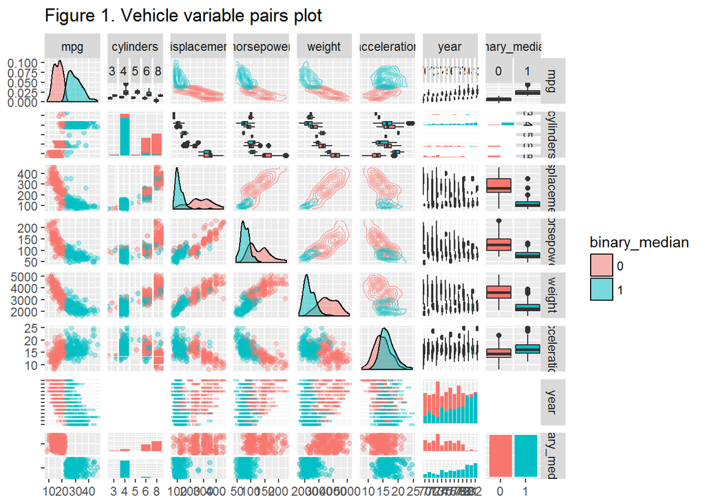

```r
# Reclassify discrete categorical variables
cat_var = c("cylinders", "origin", "year", "name", "binary_median")
for(i in cat_var){
  df[,i] = as.factor(df[,i])
}

### Visualize variable relationships
# Load required packages
require(GGally)
require(ggplot2)

# Subset predictor variables to plot and save as new data frame
df_2 = subset(x = df, select = c("mpg", "cylinders", "displacement", "horsepower", "weight", "acceleration", "year", "binary_median"))

# Produce pairs plot
#png("Figures/Figure1_pairsPlot.png", width = 8, height = 5.5, units = 'in', res = 300)
f1 = ggpairs(df_2,
              mapping = ggplot2::aes(color = binary_median),
              upper = list(continuous = wrap("density", alpha = 0.5), combo = "box"),
              lower = list(continuous = wrap("points", alpha = 0.3), combo = wrap("dot", alpha = 0.4)),
              diag = list(continuous = wrap("densityDiag", alpha = 0.5)),
              title = "Figure 1. Vehicle variable pairs plot",
              legend = c(1,1)) +
  theme(legend.position = "right")
f1
```

```r
#dev.off()
```

[figure not shown]

Figure1

```r
# Remove mpg variable from data frame
df_2 = df_2[,2:ncol(df_2)]
```

**(c)** Split the data into a training set and a test set.

```r
# Randomize dataset by assigning indices random numbers
set.seed(90210)
rand = runif(nrow(df))
df_2 = df_2[order(rand),]

# Create test (n = 40) and training sets from data frame
df_test = df_2[1:40,]
df_train = df_2[41:nrow(df),]
```

**(d)** Perform two of the following in order to predict mpg_binary:

1. *K-nearest neighbor analysis:*

```r
# Load library
require(class)

# Normalize variables to range from 0 to 1 to remove influence of variable ranges
# Create new normalized data frame for continuous predictor variables (columns 2:5)
normalize = function(x){
  return((x - min(x)) / (max(x) - min(x)))
}

df_test_continuous = data.frame(sapply(df_test[,2:5], normalize), df_test$binary_median)
df_train_continuous = data.frame(sapply(df_train[,2:5], normalize), df_train$binary_median)

colnames(df_test_continuous)[5] = "binary_median"
colnames(df_train_continuous)[5] = "binary_median"

# Confirm new data structure
print(summary(df_test_continuous))
```

```
##   displacement       horsepower         weight        acceleration
##  Min.   :0.00000   Min.   :0.0000   Min.   :0.0000   Min.   :0.000
##  1st Qu.:0.07472   1st Qu.:0.1864   1st Qu.:0.1103   1st Qu.:0.360
##  Median :0.50000   Median :0.3935   Median :0.5265   Median :0.480
##  Mean   :0.46885   Mean   :0.4314   Mean   :0.4766   Mean   :0.503
##  3rd Qu.:0.80726   3rd Qu.:0.6154   3rd Qu.:0.7498   3rd Qu.:0.644
##  Max.   :1.00000   Max.   :1.0000   Max.   :1.0000   Max.   :1.000
##  binary_median
##  0:24
##  1:16
##
##
##
##
```

```r
print(summary(df_train_continuous))
```

```
##   displacement       horsepower         weight        acceleration
##  Min.   :0.00000   Min.   :0.0000   Min.   :0.0000   Min.   :0.0000
##  1st Qu.:0.09561   1st Qu.:0.1576   1st Qu.:0.1748   1st Qu.:0.3557
##  Median :0.20026   Median :0.2500   Median :0.3313   Median :0.4464
##  Mean   :0.31360   Mean   :0.3089   Mean   :0.3762   Mean   :0.4540
##  3rd Qu.:0.49096   3rd Qu.:0.3764   3rd Qu.:0.5373   3rd Qu.:0.5476
##  Max.   :1.00000   Max.   :1.0000   Max.   :1.0000   Max.   :1.0000
##  binary_median
##  0:172
##  1:180
##
##
##
##
```

```r
# Create data frames for target variable (binary_median) prediction
df_test_target = df_2[1:40, "binary_median"]
df_train_target = df_2[41:nrow(df), "binary_median"]

# Set k value
k = floor(sqrt(nrow(df)))

# Create model
knn_mod = knn(train = df_train_continuous, test = df_test_continuous, cl = df_train_target, k = k)
table(df_test_target, knn_mod)
```

```
##               knn_mod
## df_test_target  0  1
##              0 24  0
##              1  0 16
```

```r
# Create table to visualize model results
```

|  |  | KNN model prediction |  |
| --- | --- | --- | --- |
|  |  | 0: Below_median | 1: Above_median |
| **Original Data** | 0: Below_median | **24** | 0 |
|  | 1: Above_median | 0 | **16** |

2. *Decision Tree Analsis: CART*

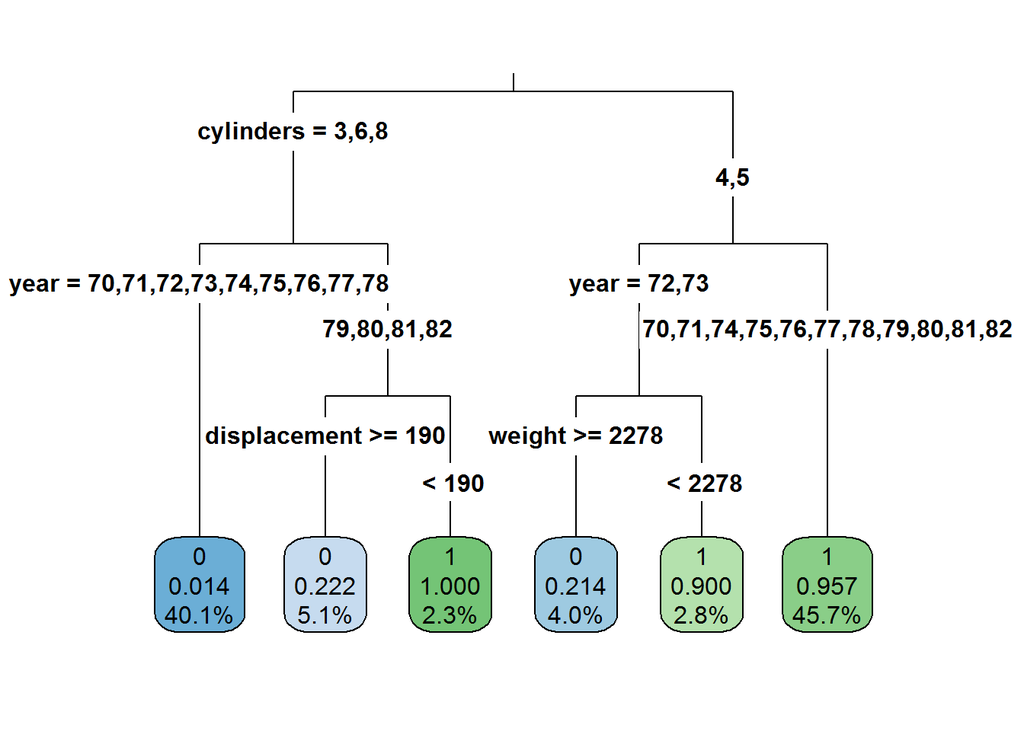

```r
# Load library
require(rpart)
require(rpart.plot)

# Specify target variable
cart_mod <- rpart(binary_median ~., data = df_train, method = "class")

# Plot model results
#png("Figures/Figure2_TreeA.png", width = 4, height = 4, units = 'in', res = 300)
rpart.plot(cart_mod, type = 3, digits = 3, fallen.leaves = TRUE)
```

```r
#dev.off()
```

[figure not shown]

*This looks wonky, let’s try re-running the model by excluding the factor ‘year’ variable.

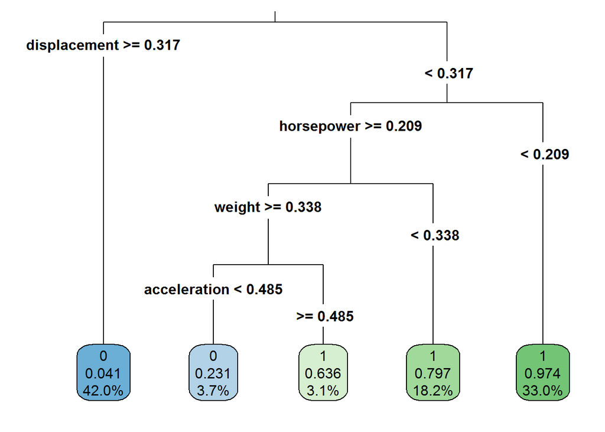

```r
# Re-run CART model to exclude categorical variables
cart_mod2 <- rpart(binary_median ~., data = df_train_continuous)

# Plot new results
#png("Figures/Figure3_TreeB.png", width = 4, height = 4, units = 'in', res = 300)
rpart.plot(cart_mod2, type = 3, digits = 3, fallen.leaves = TRUE)
```

```r
#dev.off()
```

[figure not shown]

Figure3

```r
# Predict test data based on trained model
cart_mod_test <- predict(cart_mod2, df_test_continuous, type = "class")
table(df_test_target, cart_mod_test)
```

```
##               cart_mod_test
## df_test_target  0  1
##              0 22  2
##              1  0 16
```

```r
# Create table to visualize model results
```

|  |  | CART model prediction |  |
| --- | --- | --- | --- |
|  |  | 0: Below_median | 1: Above_median |
| **Original Data** | 0: Below_median | **22** | 2 |
|  | 1: Above_median | 0 | **16** |